# Vecteurs aléatoires

# Vecteurs aléatoires

**Combien de gagnants ?**

$N > 5$ annonces publicitaires sont affichées en carrousel. Chaque annonce peut être aimé ou pas aimé par utilisateur avec la probabilité 0.5 (comme dans le cas d’un lacement d’une pièce). Une prime est associée à une publicité si la préférence de l’utilisateur (aimé ou pas aimé) est différente de celles faite par rapport à ces voisines.

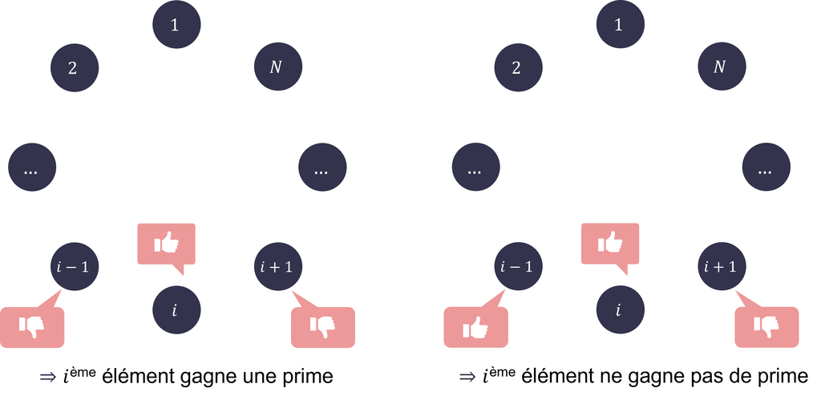

Combien de primes en moyenne vont être attribuées ?

A présent, nous allons étendre les notions vues précédement pour le cas de $n$ variables.

$$\mathbf{X} = \left[\begin{matrix}X_1 \\
X_2 \\ ... \\ X_n\end{matrix}\right]$$

**Remarque :** en terme de notation, pour les vecteurs on utilise souvent les lettres majuscules en gras, e.g. $\mathbf{X}$, $\mathbf{Y}$, $\mathbf{Z}$. Une autre façon de noter est $\underset{\bar{}}{X}$.

Graphiquement on peut représenter un vecteur aléatoire $\mathbf{X}$ de deux façons suivantes :

1. une application de $\Omega$ dans $\mathbb{R}^n$

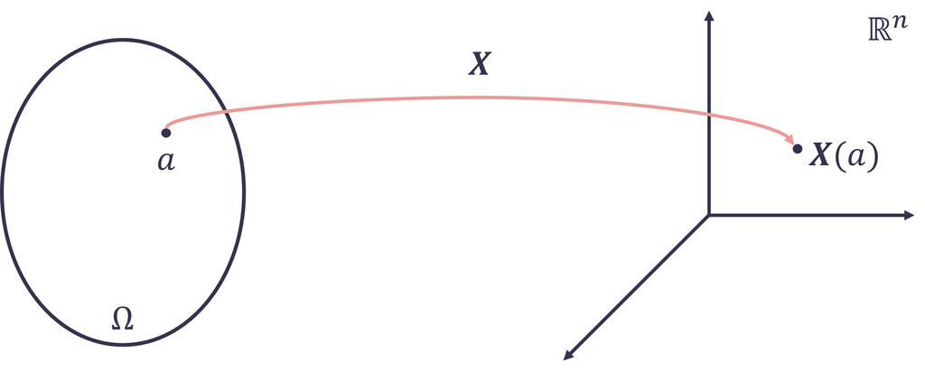

2. un vecteur de $n$ variables aléatoires

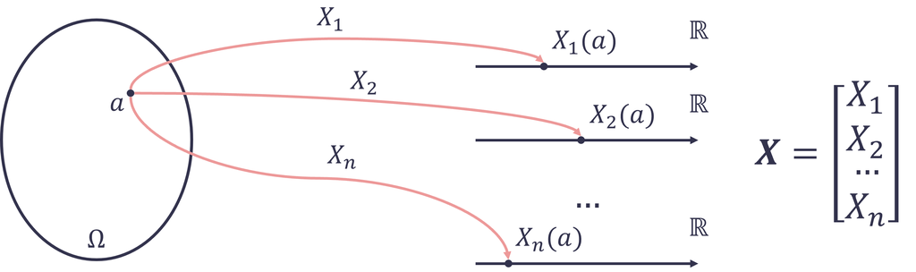

## Loi

Soit $X_1,X_2,...X_n$ $n$ v.a.r. définies sur un espace probabilisé $(\Omega, \mathcal{A}, \mathbb{P})$.

**(cas discret)** Soit $X_i, i=1,...,n$ v.a.r. discrètes.

La **fonction de masse jointe** (en. *joint probability mass function* ou *joint PMF*) est donnée par :

$$\mathbb{P}_{X_1,X_2,...,X_n}(x_1, x_2,
..., x_n) = \mathbb{P}(X_1=x_1, X_2=x_2, ..., X_n=x_n)$$
**La fonction de répartition jointe** (en. *joint CDF*) de $n$ v.a.r. $X_1,...,X_n$ est définie comme :
$$F_{X_1X_2...X_n}(x_1,x_2,...,x_n) =
\mathbb{P}([X_1\leq x_1] \ \cap\ [X_2\leq x_2]\ \cap\ ...\ \cap\ [X_n
\leq x_n])$$

**(cas continu)** Soit $X_1,X_2,...X_n$ absolument continues.

La **fonction de densité jointe** (en. *joint PDF*) $f_{X_1X_2...X_n}(x_1,x_2,...,x_n)$ est une fonction telle que pour tout ensemble $A\subset \mathbb{R}^n$ la probabilité des v.a.r. $X_1,X_2,...,X_n$ de se retrouver dans $A$ est donnée par l’intégrale de cette fonction sur l’ensemble $A$, i.e. :

$$\forall A\in \mathbb{R}^n, \
\mathbb{P}\left((X_1, X_2, ..., X_n)\in A\right) =
\int_{}...\int\limits_A...\int f_{X_1X_2...X_n}(t_1, t_2, ..., t_n)dt_1
dt_2 ... dt_n$$

La **fonction de répartition jointe** (en. *joint CDF*) de $X_1,...,X_n$ est donnée par :

$$F_{X_1X_2...X_n}(x_1,x_2,...,x_n) =
\mathbb{P}(X_1\leq x_1, X_2\leq x_2,..., X_n \leq x_n) =$$
$$=
\int_{-\infty}^{x_1}\int_{-\infty}^{x_2}...\int_{-\infty}^{x_n}f_{X_1X_2...X_n}(t_1,
t_2, ..., t_n)dt_1 dt_2 ... dt_n$$
Notons que :

- $\lim \limits_{x\to-\infty} F_{\mathbf{X}}(x,...,x) = 0$
- $\lim \limits_{x\to+\infty} F_{\mathbf{X}}(x,...,x) = 1$

Considérons un exemple suivant :

> Soit $X$, $Y$ et $Z$ trois v.a.r. absolument continues de la fonction de densité jointe :

$$f_{XYZ}(x,y,z) = \left\{
\begin{array}{@{}l@{}l} c(3x + 2y + z) & 0 \leq x \leq 1, \ 0\leq y
\leq 1, \ 0\leq z \leq 1 \\ 0 & sinon \end{array}\right.$$
où $c$ est une constante.

Trouvons $c$.

*Solution :*

Lorsqu’il s’agit de la fonction de densité jointe, le suivant est vraie :

$$\int\limits_{-\infty}^{\infty}\int\limits_{-\infty}^{\infty}\int\limits_{-\infty}^{\infty}f_{XYZ}(x,y,z)dxdydz
= 1$$

En se servant de cette expression, on peut trouver $c$. Notons qu’en dehors de $0 \leq x \leq 1, \ 0\leq y \leq 1, \ 0\leq z \leq 1$ la fonction de densité est égale à 0. Alors :

$$\int\limits_{-\infty}^{\infty}\int\limits_{-\infty}^{\infty}\int\limits_{-\infty}^{\infty}f_{XYZ}(x,y,z)dxdydz
= \int\limits_{0}^{1}\int\limits_{0}^{1}\int\limits_{0}^{1}c(3x + 2y +
z)dxdydz = 1$$

$$\int\limits_{0}^{1}\int\limits_{0}^{1}\int\limits_{0}^{1}c(3x
+ 2y + z)dxdydz =
\int\limits_{0}^{1}\int\limits_{0}^{1}c\left(\frac{3x^2}{2} + 2yx +
zx\right)\Bigg\rvert_{0}^{1}dydz =
\int\limits_{0}^{1}\int\limits_{0}^{1}c\left(\frac{3}{2} + 2y +
z\right)dydz =$$
$$=\int\limits_{0}^{1}c\left(\frac{3}{2}y +
\frac{2y^2}{2} + zy\right)\Bigg\rvert_{0}^{1}dz =
\int\limits_{0}^{1}c\left(\frac{3}{2}y + y^2 +
zy\right)\Bigg\rvert_{0}^{1}dz =\int\limits_{0}^{1}c\left(\frac{3}{2} +
1 + z\right)dz=$$
$$=\int\limits_{0}^{1}c\left(\frac{5}{2} +
z\right)dz = c\left(\frac{5}{2}z +
\frac{z^2}{2}\right)\Bigg\rvert_{0}^{1} = c\left(\frac{5}{2} +
\frac{1}{2}\right) = 3c$$
Alors :
$$3c
= 1$$
$$c = \frac{1}{3}$$

Donc, on peut substituer $c$ par sa valeur dans $f_{XYZ}$ :

$$f_{XYZ}(x,y,z) = \left\{
\begin{array}{@{}l@{}l} \frac{1}{3}(3x + 2y + z) & 0 \leq x \leq 1,
\ 0\leq y \leq 1, \ 0\leq z \leq 1 \\ 0 & sinon
\end{array}\right.$$

Comme dans le cas bivarié, il est également possible de définir la loi marginale des variables aléatoires.

Soit $\mathbf{X} = (X_1,...,X_n)$ un vecteur aléatoire de $\mathbb{R}^n$. On appelle $k^{ième}$ **loi marginale** (en. *marginal distribution*) $k\in\{1,...,n\}$ du $\mathbf{X}$ la loi de la v.a.r. $X_k$.

La densité marginale de $X_i$ peut être obtenue par l’intégration de tous les autres $X_j,\ j\neq i$, i.e. :

$$f_{X_i}(x_i) =
\int_{-\infty}^{\infty}...\int_{-\infty}^{\infty}f_{X_1X_2...X_n}(x_1,
x_2, ..., x_n)dx_1...dx_{i-1}dx_{i+1}...dx_n$$

$$F_{X_i}(x) = \mathbb{P}(X_i\leq x) =
\mathbb{P}(X_1\in\mathbb{R}, ..., X_{i-1}\in\mathbb{R}, X_i\leq x,
X_{i+1}\in\mathbb{R} ,..., X_n\in\mathbb{R}) =$$
$$= \lim\limits_{y\to
+\infty}F_X(\underbrace{y,...,y}_{i-1\
éléments},\overbrace{x}^{i^{ème}},\underbrace{y,...,y}_{à\ partir\ de\
(i+1)^{ème}})$$
Dans le cas continu :
$$F_{X_i}(x) = \int_{-\infty}^x
f_{X_i}(t_1,...,t_n)dt_i$$

> Reprenons notre exemple et trouvons la densité marginale de $X$.

Comme nous avons noté précédement, la fonction de densité jointe est égale à 0 en dehors de $0 \leq x \leq 1, \ 0\leq y \leq 1, \ 0\leq z \leq 1$. Alors pour $0\leq x\leq 1$, la densité marginale peut être calculée comme suit :

$$f_X(x) =
\int\limits_{-\infty}^{\infty}\int\limits_{-\infty}^{\infty}f_{XYZ}(x,y,z)dydz
=\int\limits_{0}^{1}\int\limits_{0}^{1}\frac{1}{3}(3x + 2y + z)dydz =
\int\limits_{0}^{1}\frac{1}{3}(3xy + 2\frac{y^2}{2} +
zy)\Bigg\rvert_{0}^{1}dz =$$

$$= \int\limits_{0}^{1}\frac{1}{3}(3x + 1
+ z)dz = \frac{1}{3}\left(3xz + z
+\frac{z^2}{2}\right)\Bigg\rvert_{0}^{1} = \frac{1}{3}\left(3x + 1 +
\frac{1}{2}\right) = \frac{1}{3}\left(3x + \frac{3}{2}\right) = x +
\frac{1}{2}$$

## Moments de vecteur aléatoire

### Espérance

Soit $\mathbf{X} = (X_1, ..., X_n)$ un vecteur aléatoire défini sur un espace probabilisé $(\Omega, \mathcal{A}, \mathbb{P})$. Soit $\mathbb{E}[X_i]\in \mathbb{R}, \forall i=1,...,n$ l’espérance de $X_i$. L’espérance de $\mathbf{X}$ est définie comme :

$$\mathbb{E}\mathbf{X} =
\left(\mathbb{E}[X_1],...,\mathbb{E}[X_n]\right) \in
\mathbb{R}^n$$

Soit $\mathbf{X} = (X_1, ..., X_n)$ un vecteur aléatoire défini sur l’espace probabilisé $(\Omega, \mathcal{A}, \mathbb{P})$.

Soit $Z = h(X_1,...,X_n)$ où $h:\mathbb{R}^n \to \mathbb{R}$ une fonction bornée et continue par morceaux.

**(cas discret)** Soit $\mathbf{X}$ a des valeurs dans $D = \mathbf{X}(\Omega) \subset \mathbb{R}^n$ sous ensemble fini ou dénombrable.

Alors, l’espérance $\mathbb{E}Z$ est donnée par :

$$\mathbb{E}Z =
\sum\limits_{k=(k_1,...,k_n)\in D} h(k_1,...,k_n)\mathbb{P}(X_1 = k_1,
..., X_n = k_n)$$
**(cas continu)** Soit $f_\mathbf{X} : \mathbb{R}^n \to \mathbb{R}$ la fonction de densité de $\mathbf{X}$.

Alors, l’espérance $\mathbb{E}Z$ est donnée par :

$$\mathbb{E}Z =
\int_{\mathbb{R}^n}h(t_1,...,t_n)f_{\mathbf{X}}(t_1,...,t_n)
dt_1...dt_n$$
lorsque cette intégrale existe.

Soient $\mathbf{X}$ et $\mathbf{Y}$ deux vecteurs aléatoires de $\mathbb{R}^n$. Soit $A \in \mathcal{M}_n(\mathbb{R})$ une matrice carrée d’ordre $n$ à coefficients réels. On a :

1. $\mathbb{E}[A\mathbf{X}] = A\ \mathbb{E}\mathbf{X}$
2. $\mathbb{E}(\mathbf{X} + \mathbf{Y}) = \mathbb{E}\mathbf{X} + \mathbb{E}\mathbf{Y}$

### Matrice de covariance

Soit $\mathbf{X} = (X_1, ..., X_n)^T$ un vecteur aléatoire dans $\mathbb{R}^n$. La **matrice de covariance** (en. *covariance matrix*), notée $\Sigma_{\mathbf{X}}$ ou $K_{\mathbf{X}\mathbf{X}}$, est une matrice carrée symétrique telle que :

$$K_{\mathbf{X}\mathbf{X}} =
\Sigma_{\mathbf{X}} = \left(Cov(X_i,X_j)\right)_{i,j=1,...,n}$$
Propriétés :

1. *symétrique*, i.e. : $Cov(X_i,X_j) = Cov(X_j,X_i),\ \forall i,j = 1,...,n$
2. *semi-définie positive*, i.e. : pour $\forall \mathbf{x} = \begin{pmatrix}x_1 & x_2 & ... &x_n\end{pmatrix}^T \in \mathbb{R}^n$ on a $\mathbf{x}^TM\mathbf{x} \geq 0$

Soit $Z = X_1 + ... + X_n$. Alors **la variance** peut être calculée comme suit :
$$Var(Z) = Cov\left(\sum_{i=1}^{n}X_i, \
\sum_{j=1}^{n}X_j\right) = \sum_{i=1}^{n}\sum_{j=1}^{n}Cov(X_i, X_j) =
\sum_{i=1}^{n}Var(X_i) + 2\sum_{i<j}Cov(X_i, X_j)$$

### Moment de l’ordre $n$

Soit $X$ une v.a.r. On appelle **moment de l’ordre $n$** (en. *$n^{th}$ moment*) de $X$ la valeur $\mathbb{E}[X^n]$.

On appelle **moment central de l’ordre $n$** (en. *$n^{th}$ central moment*) de $X$ la valeur $\mathbb{E}[(X - \mathbb{E}X)^n]$.

Ainsi, l’espérance de $X$ est le moment de l’ordre $n=1$, la variance de $X$ est le moment central de l’ordre $n=2$.

## Indépendance

Pour rappel, l’intuition derrière la notion de l’indépendance des évènements est la suivante. Les connaissances qu’on a sur un évènement (une variable aléatoire) n’ont pas d’influence sur la probabilité des évènements qui restent.

Supposons qu’on a des évènements $A_1, A_2, ..., A_n$. Le fait que tous les évènements soient indépendants implique que :

$$\mathbb{P}\left(A_5 \cap
\overline{A_6}\right) = \mathbb{P}\left(\underbrace{A_5 \cap
\overline{A_6}}_{évènement\ d'intérêt} \bigg|\ \
\underbrace{\overline{A_1} \cup A_2 \cup \left(A_3 \cap
\overline{A_4}\right) \cup A_7}_{ce\ qu'on\ sait} \right)$$
Notons que les indices des évènements (dans notre cas $5$ et $6$) formant l’évènement d’intérêt ($A_5 \cap \overline{A_6}$) sont différents des indices des évènements sur la réalisations dequels nous avons l’information ($A_1$, $A_2$, $A_3$, $A_4$, $A_7$).

Les évènements $A_1,A_2,...,A_n$ sont dits **mutuellement indépendants** (en. *independent*), si pour tous indices distincts $\forall i,j,...,m : i\neq j\neq ... \neq m$ et pour tout nombre d’évènements choisis :
$$\mathbb{P}(A_i\cap A_j\ \cap\ ... \ \cap\ A_m) =
\mathbb{P}(A_i)\times\mathbb{P}(A_j)\times...\times\mathbb{P}(A_m)$$

Les v.a.r. $X_1, X_2, ..., X_n$ sont dites **mutuellement indépendantes** (en. *mutually independent*) si $\forall (x_1,...,x_n) \in \mathbb{R}^n$, les évènements $[X_i\leq x_i], i=1,...,n$ sont *mutuellement indépendants*.

Si $X_1,...,X_n$ sont mutuellement indépendantes, alors :

$$Var\left(\sum_{i=1}^nX_i\right) =
\sum_{i=1}^n Var(X_i)$$

Les v.a.r. $X_1, X_2, ..., X_n$ sont dites **indépendantes et identiquement distribuées (i.i.d.)** (en. *independent and identically distributed (i.i.d.)*) si $\forall (x_1,...,x_n) \in \mathbb{R}^n$, les v.a.r. $X_i, i=1,...,n$ sont mutuellement indépendantes et ont la même fonction de répartition :
$$F_{X_1}(x) =
F_{X_2}(x) = ... = F_{X_n}(x), \ \forall x\in \mathbb{R}$$

Soit $X_1,...,X_n$ $n$ v.a.r. i.i.d., alors :

$$\mathbb{E}[X_1...X_n] = (indépendance) =
\mathbb{E}X_1 \times \mathbb{E}X_2 \times ... \times \mathbb{E}X_n
=$$
$$= (identiquement\
distribuées) = \mathbb{E}X_1 \times \mathbb{E}X_1 \times ... \times
\mathbb{E}X_1 = (\mathbb{E}X_1)^n$$

## Exemple

Prenons l’exemple de publicité carrousel inspiré par (Pishro-Nik 2014).

Soit $X$ le nombre de primes attribuées. Il s’agit de trouver $\mathbb{E}X$.

On numérote les annonces de 1 à $N$.

Soit $X_i$ une v.a.r. qui sert de l’indicateur si une prime est attribuée à l’annonce $i$, i.e. :

$$X_i = \left\{ \begin{array}{@{}l@{}l} 1
& \mbox{prime est attribuée à l'annonce } i\\ 0 &
sinon\end{array} \right.$$
Alors :

$$X = X_1 + X_2 + ... + X_n$$
Prenons $X_i$. La prime est attribuée dans deux cas :

1. $A = \left(\right.$ 👎$_{i-1}\cap$ 👍$_{i}\cap$ 👎$_{i+1}\left.\right)$
2. $B = \left(\right.$ 👍$_{i-1}\cap$👎$_{i}\cap$ 👍$_{i+1}\left.\right)$

Notons que les évènements (préférences) sont indépendantes. Alors :

1. $\mathbb{P}\left(\right.$👎$_{i-1}\cap$ 👍$_{i}\cap$👎$_{i+1}\left.\right) = \frac{1}{2}\times \frac{1}{2} \times \frac{1}{2} = \frac{1}{8}$
2. $\mathbb{P}\left(\right.$ 👍$_{i-1}\cap$👎$_{i}\cap$ 👍$_{i+1}\left.\right) = \frac{1}{2}\times \frac{1}{2} \times \frac{1}{2} = \frac{1}{8}$

Ainsi :

$\mathbb{P}(X_i = 1) = \mathbb{P}\left(\right.$👎$_{i-1}\cap$ 👍$_{i}\cap$👎$_{i+1}\left.\right) + \mathbb{P}\left(\right.$ 👍$_{i-1}\cap$👎$_{i}\cap$ 👍$_{i+1}\left.\right) = \frac{1}{8} + \frac{1}{8} = \frac{1}{4}$

Donc :

$$\mathbb{E}X_i = 1\times\mathbb{P}(X_i=1)
+ 0\times \mathbb{P}(X_i=0) = 1\times \frac{1}{4} + 0\times \frac{3}{4}
= \frac{1}{4}$$

Ceci est vrai pour tout $i = 1,...,N$.

Ainsi, on peut trouver $\mathbb{E}X$ comme suit :

$$\mathbb{E}X = \mathbb{E}X_1 +
\mathbb{E}X_2 + ... + \mathbb{E}X_N = N\times \mathbb{E}X_i=
N\times\frac{1}{4} = \frac{N}{4}$$

> Quelle est la variance de $X$ ?

Selon la formule :

$$Var(X) = \sum_{i=1}^N Var(X_i) +
2\sum_{i<j}Cov(X_i,X_j) = \sum_{i=1}^N Var(X_i) + \sum_{i\neq j}
Cov(X_i,X_j) =$$
$$=\sum_{i=1}^N
Var(X_i) + \sum_{i=1}^N\sum_{\begin{matrix}j=1\\i\neq j\end{matrix}}^N
Cov(X_i,X_j)$$

Considérons $X_i$. Comme noté précédement, il y a deux issues possibles (1 et 0), dont le succès ($X_i = 1$) se réalise avec la probabilité $\frac{1}{4}$. On peut donc dire que $X_i$ suit la loi de Bernoulli $X_i\sim \mathcal{B}\left(\frac{1}{4}\right)$ pour tout $i=1,...,N$. Donc :

$$Var(X_i) = p(1-p) =
\frac{1}{4}\times\left(1 - \frac{1}{4}\right) = \frac{1}{4}\times
\frac{3}{4} = \frac{3}{16}$$

Donc : $\sum_{i=1}^N Var(X_i) = N\times \frac{3}{16} = \frac{3N}{16}$

Explorons l’indépendance des $X_i$.

Prenons $i=1$ comme exemple. Afin d’évaluer la valuer de $X_i$, nous regardons les 2 voisins, i.e. avec les indices $i-1$ et $i+1$. Si $i=1$, alors $i+1=2$ et $i-1=N$ :

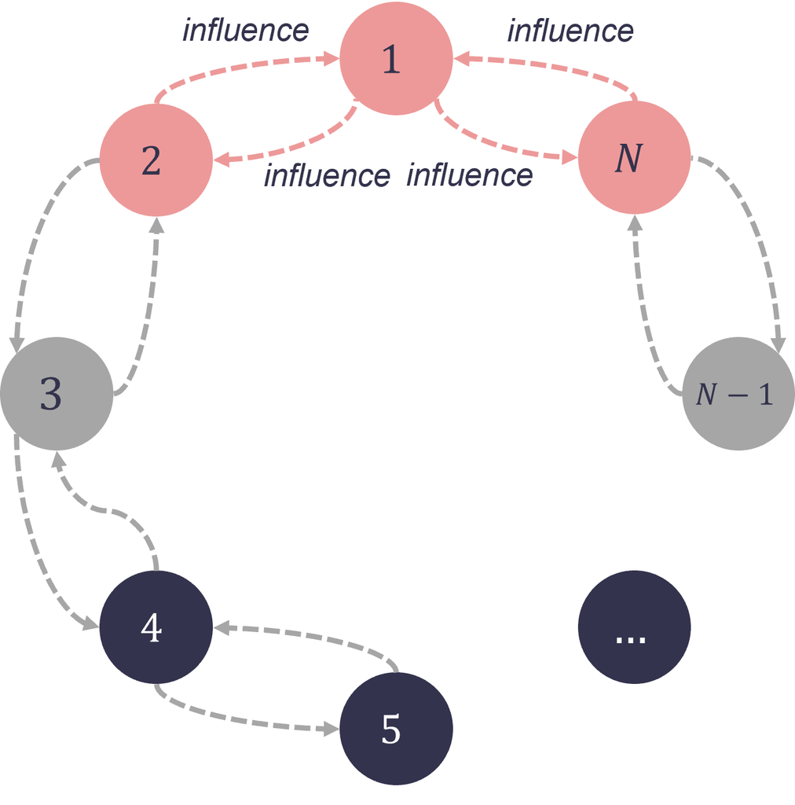

On peut généraliser cette conclusion d’une manière suivante : $X_i$ et $X_j$ sont indépendantes si $2 < |i-j| < N-2$.

Pourquoi la notion d’indépendance est utile dans notre cas ? C’est parce que la covariance de deux v.a.r. indépendantes est égale à 0, i.e. :

$$Cov(X_i,X_j) = 0,\ \forall i,j : 2 <
|i-j| < N-2$$

Illustrons cela pour $N=6$. Dans ce cas $N - 2 = 4$. La matrice de covariance est donnée par :

$$K = \begin{pmatrix}Var(X_1) &
Cov(X_1,X_2) & Cov(X_1,X_3) & \mathbf{0} & Cov(X_1,X_5)
& Cov(X_1,X_6) \\ Cov(X_2,X_1) & Var(X_2) & Cov(X_2,X_3)
& Cov(X_2,X_4) & \mathbf{0} & Cov(X_2,X_6) \\ Cov(X_3,X_1)
& Cov(X_3,X_2) & Var(X_3) & Cov(X_3,X_4) & Cov(X_3,X_5)
& \mathbf{0} \\ \mathbf{0} & Cov(X_4,X_2) & Cov(X_4,X_3)
& Var(X_4) & Cov(X_4,X_5) & Cov(X_4,X_6) \\ Cov(X_5,X_1)
& \mathbf{0} & Cov(X_5,X_3) & Cov(X_5,X_4) & Var(X_5)
& Cov(X_5,X_6) \\ Cov(X_6,X_1) & Cov(X_6,X_2) & \mathbf{0}
& Cov(X_6,X_4) & Cov(X_6,X_5) &
Var(X_6)\end{pmatrix}$$

Dans le cas de $N=7$, la matrice de covariance est donnée par :

$$\begin{pmatrix}Var(X_1) &
Cov(X_1,X_2) & Cov(X_1,X_3) & \mathbf{0} & \mathbf{0} &
Cov(X_1,X_6) & Cov(X_1,X_7)\\ Cov(X_2,X_1) & Var(X_2) &
Cov(X_2,X_3) & Cov(X_2,X_4) & \mathbf{0} & \mathbf{0} &
Cov(X_2,X_7) \\ Cov(X_3,X_1) & Cov(X_3,X_2) & Var(X_3) &
Cov(X_3,X_4) & Cov(X_3,X_5) & \mathbf{0} & \mathbf{0}\\
\mathbf{0} & Cov(X_4,X_2) & Cov(X_4,X_3) & Var(X_4) &
Cov(X_4,X_5) & Cov(X_4,X_6) & \mathbf{0}\\ \mathbf{0} &
\mathbf{0} & Cov(X_5,X_3) & Cov(X_5,X_4) & Var(X_5) &
Cov(X_5,X_6) & Cov(X_5,X_7) \\ Cov(X_6,X_1) & \mathbf{0} &
\mathbf{0} & Cov(X_6,X_4) & Cov(X_6,X_5) & Var(X_6) &
Cov(X_6,X_7) \\ Cov(X_7,X_1) & Cov(X_7,X_2) & \mathbf{0} &
\mathbf{0} & Cov(X_7,X_5) & Cov(X_7,X_6) &
Var(X_7)\end{pmatrix}$$

On peut également noter la symétrie suivante :

$Cov(X_1,X_2) = Cov(X_2,X_3) ... = Cov(X_{i-1},X_i) = Cov(X_i,X_{i+1}) ... = Cov(X_{N-1},X_N) = Cov(X_N,X_1)$

$Cov(X_1,X_3) = Cov(X_2,X_4) ... = Cov(X_{i-1},X_{i+1}) = Cov(X_i,X_{i+2}) ... = Cov(X_{N-1},X_1) = Cov(X_N,X_2)$

Pour rappel, la covariance de $X_i$ et $X_j$ est donnée par :

$$Cov(X_i,X_j) =
\mathbb{E}[X_iX_j]-\mathbb{E}X_i\mathbb{E}X_j$$

Précédement, nous avons trouvé que $\mathbb{E}X_i = \frac{1}{4}, \ \forall i=1,...,N$.

Notons que pour chaque $i=1,...,N$, il faut trouver $Cov(X_i,X_{i+1})$ et $Cov(X_i,X_{i+2})$

$$\mathbb{E}[X_iX_{i+1}] =
\mathbb{P}(X_i=1,X_{i+1} = 1)$$

Regardons sur l’exemple de $i=1$, i.e. $X_1$ et $X_2$.

Pour que $X_1 = 1$ et $X_2 = 1$, les deux cas sont possibles :

1. $A = \left(\right.$👎$_{N}\cap$ 👍$_{1}\cap$👎$_{2}\cap$ 👍$_{3}\left.\right)$
2. $B = \left(\right.$ 👍$_{N}\cap$👎$_{1}\cap$👍$_{2}\cap$ 👎$_{3}\left.\right)$

Dont les probabilités sont données par :

1. $\mathbb{P}(A) = \frac{1}{2}\times\frac{1}{2}\times\frac{1}{2}\times\frac{1}{2} = \frac{1}{16}$
2. $\mathbb{P}(B) = \frac{1}{2}\times\frac{1}{2}\times\frac{1}{2}\times\frac{1}{2} = \frac{1}{16}$

Donc :

$$\mathbb{E}[X_iX_{i+1}] =
\mathbb{P}(X_i=1,X_{i+1} = 1) = \mathbb{P}(A) +\mathbb{P}(B) =
\frac{1}{16} + \frac{1}{16} = \frac{1}{8}$$

Alors :

$$Cov(X_i,X_{i+1}) =
\mathbb{E}[X_iX_{i+1}]-\mathbb{E}X_i\mathbb{E}X_{i+1} = \frac{1}{8} -
\frac{1}{4}\times\frac{1}{4} = \frac{1}{8} - \frac{1}{16} =
\frac{1}{16}$$

Maintenant trouvons $\mathbb{E}[X_{i}X_{i+2}] = \mathbb{P}(X_i=1, X_{i+2}=1)$

Reprenons l’exemple de $i=1$. Deux options sont possibles :

1. $A = \left(\right.$👎$_{N}\cap$ 👍$_{1}\cap$👎$_{2}\cap$ 👍$_{3}\cap$👎$_4\left.\right)$
2. $B = \left(\right.$ 👍$_{N}\cap$ 👎$_{1}\cap$ 👍$_{2}\cap$ 👎$_{3}\cap$ 👍$_4\left.\right)$

Les probabilités de ces deux évènements sont données par :

1. $\mathbb{P}(A) = \frac{1}{2}\times\frac{1}{2}\times\frac{1}{2}\times\frac{1}{2}\times\frac{1}{2} = \frac{1}{32}$
2. $\mathbb{P}(B) = \frac{1}{2}\times\frac{1}{2}\times\frac{1}{2}\times\frac{1}{2}\times\frac{1}{2} = \frac{1}{32}$

Donc :

$$\mathbb{E}[X_{i}X_{i+2}] =
\mathbb{P}(X_i=1, X_{i+2}=1) = \mathbb{P}(A) + \mathbb{P}(B) =
\frac{1}{32} + \frac{1}{32} = \frac{1}{16}$$
Donc :

$$Cov(X_i,X_{i+2}) =
\mathbb{E}[X_iX_{i+2}] - \mathbb{E}X_i\times\mathbb{E}X_{i+2} =
\frac{1}{16} - \frac{1}{4}\times \frac{1}{4} = \frac{1}{16} -
\frac{1}{16} = 0$$

Ainsi, nous pouvons trouver $\sum_{\begin{matrix}i=1 \\i\neq j\end{matrix}}^N Cov(X_i,X_j)$ utilisé dans la formule de $Var(X)$ :

$$\sum_{i=1}^N\sum_{\begin{matrix}j=1\\j\neq
i\end{matrix}}^N Cov(X_i,X_j) = 2N\times Cov(X_1,X_2) + 2N\times
Cov(X_1,X_3) = 2N\times \frac{1}{16} + 2N\times 0 =
\frac{2N}{16}$$

La formule finale est donc :

$$Var(X) = \frac{3N}{16} + \frac{2N}{16} +
0 = \frac{5N}{16}$$

## Fonction caractéristique et fonction génératrice

Dans le cas bivariée, nous avons défini la fonction de densité de $Z = X + Y$ dans le cas où $X$ et $Y$ étaient indépendantes. Pour cela, nous avons utilisé la notion du produit de convolution, i.e. :

$$f_Z(z) = f_X(z)*f_Y(z) =
\int\limits_{-\infty}^{\infty}f_X(x)f_Y(z-x)dx$$
Pour le cas de $n$ v.a.r. mutuellement indépendantes $X_1, X_2, ..., X_n$, on pourrait se servir du même principe et obtenir la fonction de densité de $Z = X_1 + ... + X_n$ comme suit :

$$f_Z(z) = f_{X_1}(z) * f_{X_2}(z)\ *\
...\ *\ f_{X_n}(z)$$
Cependant, cette approche devient assez coûteuse en terme de calcul. Ainsi, la fonction caractéristique et la fonction génératrice sont à privilégier dans ce cas-là.

Soit $\mathbf{X} = (X_1,...,X_n)$ un vecteur aléatoire dans $\mathbb{R}^n$. La fonction $\phi_{\mathbf{X}}$ définie pour $\forall \tau = (\tau_1,...,\tau_n)\in\mathbb{R}^n$ est appellée **fonction caractéristique** (en. *characteristic function*) de $\mathbf{X}$ qui est donnée par :
$$\phi_{\mathbf{X}}(\tau) =
\mathbb{E}\left(\exp\left(i\sum_{i=1}^{n}\tau_kX_k\right)\right) =
\mathbb{E}\left[e^{i(\tau.\mathbf{X})}\right]$$
où $\tau.\mathbf{X} \in \mathbb{R}$ est le produit scalaire entre deux vecteurs.

Soit $\mathbf{X}$ un vecteur aléatoire de fonction caractéristique $\phi_\mathbf{X}(\tau)$. Pour toute matrice $\forall A\in \mathcal{M}_n(\mathbb{R})$ et vecteur $\forall \mathbf{B}\in \mathbb{R}^n$, la fonction caractéristique du vecteur aléatoire $\mathbf{Y} = A\mathbf{X} + \mathbf{B}$ est donnée par :

$$\phi_{\mathbf{Y}}(\tau) =
e^{i(\tau.\mathbf{B})}\phi_{\mathbf{X}}(\tau A)$$
où $\tau A \in \mathbb{R}^n$ est le produit matriciel.

Soit $\mathbf{X} = (X_1,...,X_n)$ un vecteur aléatoire discret dans $\mathbb{R}^n$. On appelle **fonction génératrice** (en. *generating function*) de $\mathbf{X}$, notée $G_{\mathbf{X}}(s)$, la fonction définie pour $\forall s=(s_1,...,s_n)\in [0,1]^n$ comme suit :

$$G_\mathbf{X}(s) =
\mathbb{E}\left[s_1^{X_1}...s_n^{X_n}\right]$$

Soit $X$ une v.a.r. On appelle **fonction génératrice des moments** (en. *moment generating function* ou *MGF*) de $X$, notée $M_{X}(s)$, la fonction définie comme :
$$M_{X}(s) =
\mathbb{E}\left[e^{sX}\right]$$
$M_X(s)$ existe s’il existe une constante $a > 0, a\in \mathbb{R}$ telle que $M_X(s)$ est finie $\forall s\in [-a,a]$.

En se servant de séries de Taylor pour $e^x, \forall x\in \mathbb{R}$ :
$$e^x = 1 + x + \frac{x^2}{2!} + \frac{x^3}{3!} +
... = \sum_{k=0}^{\infty}\frac{x^k}{k!}$$
On peut obtenir que :

$$M_{X}(s) = \mathbb{E}\left[e^{sX}\right]
= \mathbb{E}\left[\sum_{k=0}^{\infty}\frac{(sX)^k}{k!}\right] =
\mathbb{E}\left[\sum_{k=0}^{\infty}\frac{s^kX^k}{k!}\right] =
\sum_{k=0}^{\infty}\mathbb{E}[X^k]\frac{s^k}{k!}$$

Soit $X$ une v.a.r. de fonction génératrice des moments $M_X(s)$. On obtient :

$$M_{X}(s) = \mathbb{E}\left[e^{sX}\right]
= \sum_{k=0}^{\infty}\mathbb{E}[X^k]\frac{s^k}{k!}$$
où

$$\mathbb{E}[X^k] =
\frac{d^k}{ds^k}M_X(s)\rvert_{s=0}$$

Soit $X_1,X_2,...,X_n$ $n$ v.a.r. mutuellement indépendantes de fonction génératrice des moments $M_{X_i}, \ \forall i =1,...,n$. Soit $Z = X_1 + ... + X_n$.

Alors la fonction génératrice des moments $M_Z(s)$ est donnée par :

$$M_Z(s) = M_{X_1}(s)\times
M_{X_2}(s)\times ... \times M_{X_n}(s)$$

## Quelques distributions importantes

**Loi multinomiale** (en. *multinomial distribution*), notée $\mathcal{M}(n,p_1,...,p_k)$ où $n\in \mathbb{N^{*}}$ et $p_i\in ]0,1[ \ \forall i\in\{1,...,k\}$ est la généralisation de la loi binomiale, i.e. :

$$\mathcal{B}(n,p) =
\mathcal{M}(n,p,1-p)$$

La fonction de masse de $\mathcal{M}(n,p_1,...,p_k)$ est définie par :
$$\mathbb{P}(X_1=\eta_1,...,X_n=\eta_n)
= \frac{n!}{\eta_1!\times...\times \eta_k!}p_1^{\eta_1}\times...\times
p_k^{\eta_k}, \ \forall \eta=(\eta_1,...,\eta_k)\in
\mathbb{N}^k$$
où :

- $\sum_{i=1}^k \eta_i = n$
- $\sum_{i=1}^k p_i = 1$

La **loi normale $n$-dimensionnelle** ou **loi normale multidimensionnelle** (en. *multivariate normal distribution* ou *multivariate Gaussian distribution* ou *joint normal distribution*), notée $\mathcal{N}(\mu, \Sigma)$ où $\mu = (\mu_1,...,\mu_n)\in\mathbb{R}^n$ et $\Sigma$ est une matrice de covariance (carrée d’ordre $n$, symétrique définie positive), est la généralisation de la loi normale $\mathcal{N}(m, \sigma^2)$ où $\mu = (m)$ et $\Sigma = (\sigma^2)$

$$f_{\mathbf{X}}(x_1,...,x_n) =
\frac{1}{\sqrt{(2\pi)^{n}\det\Sigma}}\exp\left(-\frac{1}{2}(\mathbf{x}-\mathbf{\mu})^T
\Sigma^{-1}(\mathbf{x}-\mathbf{\mu})\right)$$
où

- $(\mathbf{x}-\mathbf{\mu})^T$ désigne le vecteur colonne composé de $x_i - \mu_i, \ \forall i\in \{1,...,n\}$
- $\Sigma^{-1}$ désigne l’inverse de la matrice $\Sigma$

La valeur $\sqrt{(\mathbf{x}-\mathbf{\mu})^T \Sigma^{-1}(\mathbf{x}-\mathbf{\mu})}$ est appelé [**la distance de Mahalanobis**](https://fr.wikipedia.org/wiki/Distance_de_Mahalanobis) (en. [*Mahalanobis distance*](https://en.wikipedia.org/wiki/Mahalanobis_distance)) entre le point $\mathbf{x}$ et l’espérance $\mathbf{\mu}$.

## Somme de $n$ v.a.r.

Soit $X_1,...,X_n$ $n$ v.a.r. mutuellement indépendantes.

Soit $S = \sum_{i=1}^n X_i$.

**(cas discret)**

Soit $X_i, i=1,...,n$ v.a.r. discrètes de fonction génératrice $G_{X_i}$.

Alors, la fonction génératrice $G_S(s)$ de $S$ pour $\forall s\in [0,1]$ est donnée par :

$$G_S(s) = \prod_{i=1}^n
G_{X_i}(s)$$

**(cas continu)**

Soit $\phi_{X_i}$ une fonction caractéristique de $X_i, i=1,...,n$.

Alors, la fonction caractéristique de $S$ pour $\forall t\in \mathbb{R}$ est donnée par :

$$\phi_S(t) = \prod_{i=1}^n
\phi_{X_i}(t)$$

Soit $X_1, X_2, ..., X_n$ $n$ v.a.r. mutuellement indépendantes de même loi de Bernoulli de paramètre $p$, c.à.d. $\forall i = 1,...,n,\ X_i \sim \mathcal{B}(p)$. Alors, la v.a.r. définie comme la somme $\sum_{i=1}^n X_i$ suit une loi binomiale de paramètre $(n,p)$.

Soit $X_1, X_2, ..., X_n$ $n$ v.a.r. mutuellement indépendantes, dont chaque $X_k, \ \forall k \in \{1,...,n\}$ suit une loi normale $\mathcal{N}(\mu_k, \sigma_k^2)$.

Alors, la v.a.r. définie comme la somme $\sum_{i=1}^n X_i$ suit une loi normale $\mathcal{N}(\mu, \sigma^2)$, où :

- $\mu = \sum\limits_{k=1}^{n}\mu_k$
- $\sigma^2 = \sum\limits_{k=1}^{n}\sigma^2_k$

Si $\forall k=\{1,...,n\}$, $X_k\sim\mathcal{N}(0,1)$, alors $T = \sum\limits_{k=1}^{n}X_k^2$ suit la loi Chi-Carré à $n$ degré de liberté, notée $\chi^2_n$ ou $\chi^2(n)$.

**Identité de Wald** ou **formule de Wald** (en. *Wald’s equation* ou *Wald’s identity* ou *Wald’s lemma*) :

Soit $(\Omega, \mathcal{P}(\Omega), \mathbb{P})$ un espace probabilisé discret.

Soit $N$ une v.a.r. discrète définie sur $\Omega$ à valeurs dans $\mathbb{N}^*$ de fonction génératrice $G_N$.

Soit $X_1,...,X_N$ des v.a.r. i.i.d. définies sur $\Omega$ de fonction génératrice commune $G_X$.

Soit $S$ une v.a.r. définie comme :
$$S : \omega\in \Omega\to S(\omega) =
\sum_{i=1}^{N(\omega)}X_i(\omega)$$
Alors l’espérance de $S$ est donnée par :

$$\mathbb{E}[S] = \mathbb{E}[X_i]\times
\mathbb{E}[N]$$

$S$ admet pour fonction génératrice :

$\forall s\in [0,1], \ G_S(s) = G_N(G_X(s))$

La variance de $S$ est donnée par :

$$Var(S) = \mathbb{E}[N]\times Var(X_i) +
Var(N)\times(\mathbb{E}[X_i])^2$$

# Liens utiles

1. Jeremy Orloff, and Jonathan Bloom. *18.05 Introduction to Probability and Statistics*. Spring 2014. Massachusetts Institute of Technology: MIT OpenCourseWare, https://ocw.mit.edu. License: Creative Commons BY-NC-SA.
2. [Basic probability: Joint, marginal and conditional probability | Independence](https://www.youtube.com/watch?v=SrEmzdOT65s&t=32s) by zedstatistics
3. [Joint PDFs](https://www.youtube.com/watch?v=O4QYcoxuLHE) by MIT OpenCourseWare
4. [Mean of sum and difference of random variables](https://youtu.be/RYSN1CARHtE) by Khan Academy
5. [Variance of sum and difference of random variables](https://www.youtube.com/watch?v=3VXhi_0Mclg) by Khan Academy

# References

Pishro-Nik, Hossein. 2014. *Introduction to Probability, Statistics, and Random Processes*. Blue Bell, PA: Kappa Research, LLC. https://www.probabilitycourse.com/.

Stéphane Balac, and Olivier Mazet. n.d. “Introduction aux Probabilités.” Centre de Mathématiques. Institut National des Sciences Appliquées de Lyon. Accessed May 13, 2021. https://perso.univ-rennes1.fr/stephane.balac/publis/polypbs.pdf.

Tsitsiklis, John, and Patrick Jaillet. 2018. “RES.6-012 Introduction to Probability. MIT OpenCourseWare.” 2018. https://ocw.mit.edu/resources/res-6-012-introduction-to-probability-spring-2018/.